# Appendix

Usage-based AI exposure across Australia’s earnings distribution

Author

Luc Taya, Economics (Honours) graduate, University of Western Australia

Every table here is read from pipeline output. File paths refer to the project repository. Differences in exposure are in exposure points (exposure × 100); rank gaps are in percentile points. Items added after the first results, including those added after review of the first draft, are labelled.

## 1 Alternative specifications

The main text uses one specification: weighting scheme 1, all units, EEH weekly earnings. This section reports every alternative, including those that do not hold under the rule in the Methods section.

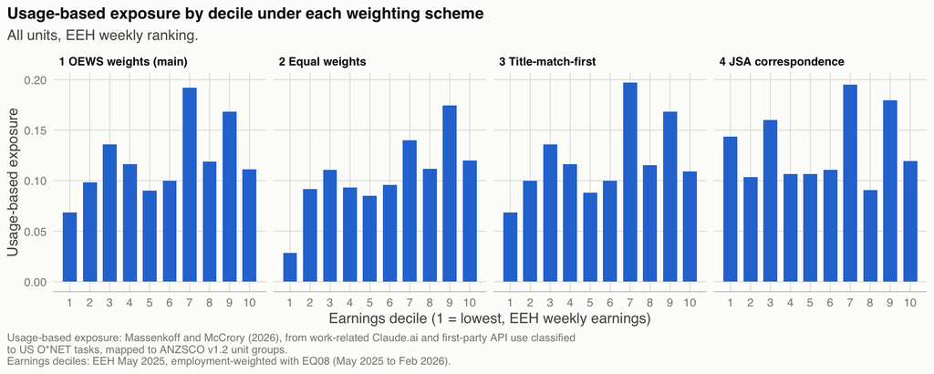

Usage-based exposure by decile under each weighting scheme.

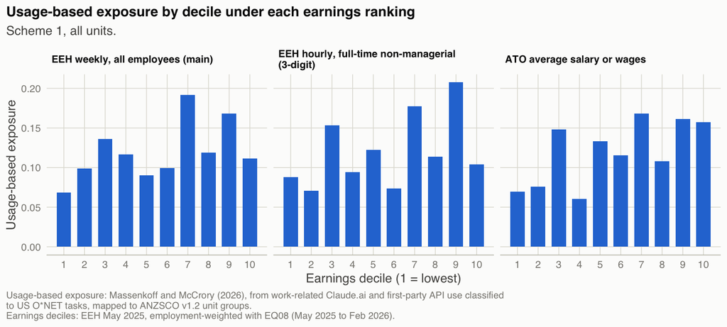

Usage-based exposure by decile under each earnings ranking.

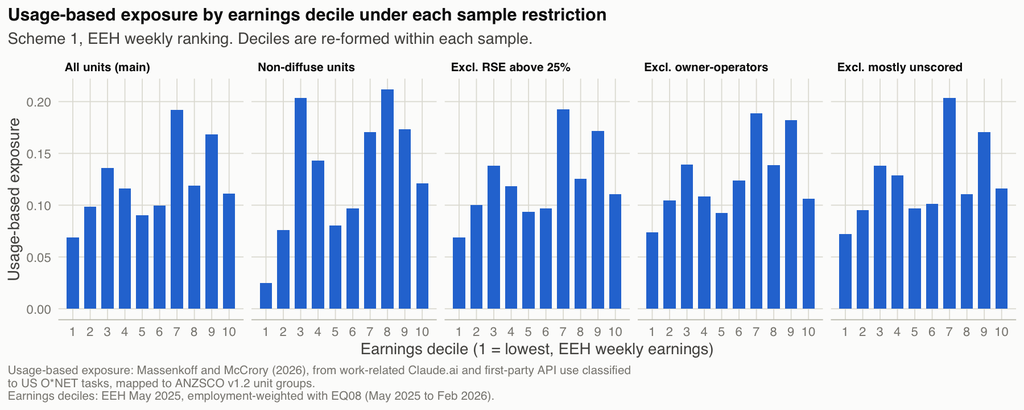

Usage-based exposure by decile under each sample restriction.

## 2 Sensitivity table

Decile profiles of usage-based exposure under every weighting scheme, sample and earnings ranking. “Holds” applies the rule in the Methods section against the primary specification (scheme 1, all units, EEH weekly earnings): the OLS slope of the decile means (shown, in exposure points per decile) has the main profile’s sign, and the Spearman correlation with the main profile is at least 0.7. The concentration index (CI) and the rank index (rank CI, added after the first results) summarise the whole distribution.

| Scheme | Sample | Ranking | Decile 1 | Decile 10 | Top minus bottom | Slope | Spearman with primary | CI | Rank CI | Holds |
| --- | --- | --- | --- | --- | --- | --- | --- | --- | --- | --- |
| 1 OEWS | All units | EEH weekly | 0.069 | 0.111 | 4.3 | 0.62 | 1.00 | 0.089 | 0.073 | yes |
| 1 OEWS | All units | EEH hourly (cube 13) | 0.088 | 0.104 | 1.6 | 0.67 | 0.73 | 0.093 | 0.085 | yes |
| 1 OEWS | All units | ATO salary | 0.070 | 0.157 | 8.8 | 0.90 | 0.62 | 0.132 | 0.095 | no |
| 1 OEWS | Non-diffuse | EEH weekly | 0.025 | 0.121 | 9.6 | 1.02 | 0.87 | 0.137 | 0.112 | yes |
| 1 OEWS | Non-diffuse | EEH hourly (cube 13) | 0.050 | 0.111 | 6.1 | 0.91 | 0.89 | 0.114 | 0.104 | yes |
| 1 OEWS | Non-diffuse | ATO salary | 0.034 | 0.162 | 12.8 | 1.49 | 0.50 | 0.192 | 0.143 | no |
| 1 OEWS | Excl. RSE above 25% | EEH weekly | 0.069 | 0.111 | 4.2 | 0.63 | 0.99 | 0.089 | 0.075 | yes |
| 1 OEWS | Excl. RSE above 25% | EEH hourly (cube 13) | 0.088 | 0.108 | 2.0 | 0.71 | 0.73 | 0.098 | 0.090 | yes |
| 1 OEWS | Excl. RSE above 25% | ATO salary | 0.071 | 0.155 | 8.4 | 0.92 | 0.68 | 0.130 | 0.095 | no |
| 1 OEWS | Excl. owner-operators (draft) | EEH weekly | 0.074 | 0.106 | 3.2 | 0.67 | 0.96 | 0.094 | 0.078 | yes |
| 1 OEWS | Excl. owner-operators (draft) | EEH hourly (cube 13) | 0.089 | 0.113 | 2.3 | 0.79 | 0.64 | 0.102 | 0.093 | no |
| 1 OEWS | Excl. owner-operators (draft) | ATO salary | 0.074 | 0.144 | 7.0 | 0.95 | 0.82 | 0.130 | 0.096 | yes |
| 1 OEWS | Excl. mostly unscored (added after results) | EEH weekly | 0.072 | 0.116 | 4.4 | 0.62 | 0.95 | 0.083 | 0.073 | yes |
| 1 OEWS | Excl. mostly unscored (added after results) | EEH hourly (cube 13) | 0.087 | 0.107 | 2.0 | 0.72 | 0.65 | 0.093 | 0.086 | no |
| 1 OEWS | Excl. mostly unscored (added after results) | ATO salary | 0.072 | 0.164 | 9.2 | 0.95 | 0.73 | 0.128 | 0.097 | yes |
| 2 Equal | All units | EEH weekly | 0.028 | 0.120 | 9.2 | 0.94 | 0.88 | 0.152 | 0.096 | yes |
| 2 Equal | All units | EEH hourly (cube 13) | 0.055 | 0.107 | 5.2 | 1.02 | 0.83 | 0.162 | 0.111 | yes |
| 2 Equal | All units | ATO salary | 0.025 | 0.177 | 15.2 | 1.16 | 0.60 | 0.188 | 0.116 | no |
| 2 Equal | Non-diffuse | EEH weekly | 0.021 | 0.140 | 11.9 | 1.14 | 0.79 | 0.165 | 0.121 | yes |
| 2 Equal | Non-diffuse | EEH hourly (cube 13) | 0.030 | 0.129 | 9.9 | 1.11 | 0.93 | 0.156 | 0.122 | yes |
| 2 Equal | Non-diffuse | ATO salary | 0.023 | 0.170 | 14.7 | 1.47 | 0.45 | 0.213 | 0.150 | no |
| 2 Equal | Excl. RSE above 25% | EEH weekly | 0.028 | 0.120 | 9.2 | 0.96 | 0.89 | 0.153 | 0.099 | yes |
| 2 Equal | Excl. RSE above 25% | EEH hourly (cube 13) | 0.056 | 0.111 | 5.5 | 1.06 | 0.83 | 0.168 | 0.117 | yes |
| 2 Equal | Excl. RSE above 25% | ATO salary | 0.025 | 0.173 | 14.8 | 1.19 | 0.58 | 0.186 | 0.116 | no |
| 2 Equal | Excl. owner-operators (draft) | EEH weekly | 0.030 | 0.114 | 8.4 | 1.02 | 0.82 | 0.160 | 0.107 | yes |
| 2 Equal | Excl. owner-operators (draft) | EEH hourly (cube 13) | 0.057 | 0.117 | 5.9 | 1.16 | 0.67 | 0.175 | 0.127 | no |
| 2 Equal | Excl. owner-operators (draft) | ATO salary | 0.026 | 0.156 | 13.0 | 1.23 | 0.83 | 0.189 | 0.122 | yes |
| 2 Equal | Excl. mostly unscored (added after results) | EEH weekly | 0.029 | 0.125 | 9.6 | 0.96 | 0.89 | 0.148 | 0.097 | yes |
| 2 Equal | Excl. mostly unscored (added after results) | EEH hourly (cube 13) | 0.056 | 0.109 | 5.2 | 1.06 | 0.62 | 0.162 | 0.111 | no |
| 2 Equal | Excl. mostly unscored (added after results) | ATO salary | 0.025 | 0.184 | 15.9 | 1.22 | 0.64 | 0.186 | 0.118 | no |
| 3 Title | All units | EEH weekly | 0.069 | 0.109 | 4.1 | 0.60 | 0.98 | 0.087 | 0.065 | yes |
| 3 Title | All units | EEH hourly (cube 13) | 0.088 | 0.102 | 1.4 | 0.63 | 0.73 | 0.089 | 0.074 | yes |
| 3 Title | All units | ATO salary | 0.070 | 0.153 | 8.4 | 0.90 | 0.62 | 0.131 | 0.087 | no |
| 3 Title | Non-diffuse | EEH weekly | 0.025 | 0.123 | 9.9 | 1.03 | 0.87 | 0.137 | 0.099 | yes |
| 3 Title | Non-diffuse | EEH hourly (cube 13) | 0.050 | 0.113 | 6.4 | 0.90 | 0.83 | 0.113 | 0.090 | yes |
| 3 Title | Non-diffuse | ATO salary | 0.033 | 0.164 | 13.0 | 1.52 | 0.50 | 0.196 | 0.130 | no |
| 3 Title | Excl. RSE above 25% | EEH weekly | 0.069 | 0.109 | 4.0 | 0.61 | 0.99 | 0.087 | 0.067 | yes |
| 3 Title | Excl. RSE above 25% | EEH hourly (cube 13) | 0.088 | 0.106 | 1.8 | 0.67 | 0.72 | 0.094 | 0.079 | yes |
| 3 Title | Excl. RSE above 25% | ATO salary | 0.071 | 0.150 | 7.9 | 0.92 | 0.71 | 0.129 | 0.086 | yes |
| 3 Title | Excl. owner-operators (draft) | EEH weekly | 0.074 | 0.104 | 3.0 | 0.65 | 0.94 | 0.091 | 0.071 | yes |
| 3 Title | Excl. owner-operators (draft) | EEH hourly (cube 13) | 0.089 | 0.110 | 2.1 | 0.76 | 0.64 | 0.097 | 0.084 | no |
| 3 Title | Excl. owner-operators (draft) | ATO salary | 0.074 | 0.139 | 6.5 | 0.94 | 0.84 | 0.129 | 0.089 | yes |
| 3 Title | Excl. mostly unscored (added after results) | EEH weekly | 0.072 | 0.114 | 4.2 | 0.60 | 0.93 | 0.080 | 0.065 | yes |
| 3 Title | Excl. mostly unscored (added after results) | EEH hourly (cube 13) | 0.087 | 0.105 | 1.8 | 0.68 | 0.65 | 0.088 | 0.075 | no |
| 3 Title | Excl. mostly unscored (added after results) | ATO salary | 0.072 | 0.159 | 8.7 | 0.94 | 0.76 | 0.128 | 0.089 | yes |
| 4 JSA links | All units | EEH weekly | 0.144 | 0.119 | -2.4 | 0.14 | 0.47 | 0.029 | 0.043 | no |
| 4 JSA links | All units | EEH hourly (cube 13) | 0.138 | 0.111 | -2.7 | 0.26 | 0.56 | 0.039 | 0.059 | no |
| 4 JSA links | All units | ATO salary | 0.136 | 0.163 | 2.7 | 0.35 | 0.32 | 0.062 | 0.061 | no |
| 4 JSA links | Non-diffuse | EEH weekly | 0.025 | 0.145 | 12.1 | 0.94 | 0.84 | 0.129 | 0.098 | yes |
| 4 JSA links | Non-diffuse | EEH hourly (cube 13) | 0.033 | 0.136 | 10.3 | 0.88 | 0.77 | 0.119 | 0.099 | yes |
| 4 JSA links | Non-diffuse | ATO salary | 0.022 | 0.155 | 13.3 | 1.34 | 0.49 | 0.182 | 0.127 | no |
| 4 JSA links | Excl. RSE above 25% | EEH weekly | 0.145 | 0.120 | -2.5 | 0.14 | 0.47 | 0.028 | 0.044 | no |
| 4 JSA links | Excl. RSE above 25% | EEH hourly (cube 13) | 0.136 | 0.115 | -2.1 | 0.30 | 0.54 | 0.044 | 0.062 | no |
| 4 JSA links | Excl. RSE above 25% | ATO salary | 0.139 | 0.159 | 2.0 | 0.38 | 0.36 | 0.059 | 0.060 | no |
| 4 JSA links | Excl. owner-operators (draft) | EEH weekly | 0.155 | 0.117 | -3.9 | 0.16 | 0.60 | 0.033 | 0.048 | no |
| 4 JSA links | Excl. owner-operators (draft) | EEH hourly (cube 13) | 0.140 | 0.122 | -1.8 | 0.43 | 0.38 | 0.052 | 0.070 | no |
| 4 JSA links | Excl. owner-operators (draft) | ATO salary | 0.146 | 0.142 | -0.4 | 0.39 | 0.49 | 0.063 | 0.064 | no |
| 4 JSA links | Excl. mostly unscored (added after results) | EEH weekly | 0.152 | 0.127 | -2.5 | 0.26 | 0.39 | 0.037 | 0.048 | no |
| 4 JSA links | Excl. mostly unscored (added after results) | EEH hourly (cube 13) | 0.130 | 0.117 | -1.3 | 0.37 | 0.35 | 0.045 | 0.061 | no |
| 4 JSA links | Excl. mostly unscored (added after results) | ATO salary | 0.143 | 0.172 | 2.8 | 0.54 | 0.52 | 0.073 | 0.067 | no |

## 3 The profile without decile boundaries

Added after review of the first draft. Decile means can exaggerate single-unit spikes, so the profile is also shown as a smoothed curve over earnings percentiles.

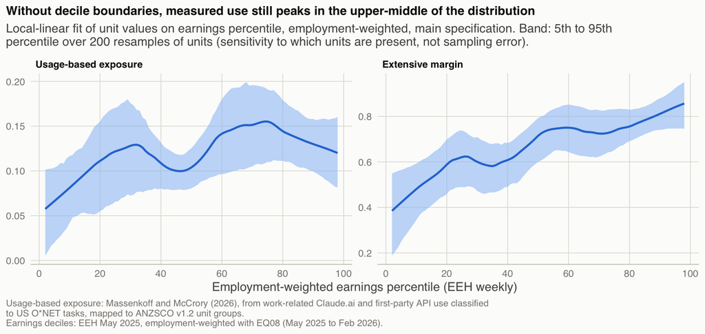

Smoothed profile over earnings percentiles, main specification.

## 4 Margins, lower bound and capability analogue by decile

Main specification. The log decomposition compares each decile with decile 1: $\ln(e_d/e_1)=\ln(m_d/m_1)+\ln(i_d/i_1)$. The lower bound counts linked US occupations without a score as zero instead of renormalising over scored ones. The capability analogue applies the same weights to an indicator of a positive Eloundou et al. beta. All three were added after review of the first draft.

| Decile | Exposure | Lower bound | Extensive margin | Intensity | Share of linked occupations with beta > 0 | Extensive share of log difference from decile 1 |
| --- | --- | --- | --- | --- | --- | --- |
| 1 | 0.069 | 0.064 | 0.388 | 0.177 | 0.866 |  |
| 2 | 0.099 | 0.094 | 0.561 | 0.176 | 0.864 | 102% |
| 3 | 0.136 | 0.124 | 0.672 | 0.202 | 0.975 | 80% |
| 4 | 0.116 | 0.112 | 0.555 | 0.210 | 0.978 | 68% |
| 5 | 0.090 | 0.082 | 0.658 | 0.137 | 0.970 | 192% |
| 6 | 0.100 | 0.092 | 0.793 | 0.126 | 0.994 | 192% |
| 7 | 0.192 | 0.182 | 0.695 | 0.276 | 0.987 | 57% |
| 8 | 0.119 | 0.105 | 0.668 | 0.178 | 0.983 | 99% |
| 9 | 0.168 | 0.140 | 0.860 | 0.196 | 0.998 | 89% |
| 10 | 0.111 | 0.103 | 0.814 | 0.137 | 0.972 | 153% |

## 5 Concentration indices for every measure

Main specification. The level index $2\,\mathrm{cov}(e,r)/\bar e$ depends on each measure’s mean and is not comparable across measures. The rank index $4\,\mathrm{cov}(R_e,r)$ is; without ties it equals one third of the weighted Spearman correlation with earnings. The Erreygers index applies to measures bounded on $[0,1]$. The generalised index $2\,\mathrm{cov}(e,r)$ is in the measure’s own units. AIOE takes negative values, so its level and Erreygers indices are not defined. Rank, Erreygers and generalised indices were added after review of the first draft.

| Measure | Level | Rank | Erreygers | Generalised | Employment covered |
| --- | --- | --- | --- | --- | --- |
| Usage-based exposure | 0.089 | 0.073 | 0.043 | 0.0107 | 99.1% |
| Usage-based exposure, lower bound | 0.078 | 0.076 | 0.034 | 0.0085 | 99.1% |
| Extensive margin | 0.097 | 0.084 | 0.259 | 0.0649 | 99.1% |
| Share of linked occupations with beta > 0 | 0.022 | 0.063 | 0.083 | 0.0208 | 100.0% |
| JSA automation | 0.013 | 0.035 | 0.020 | 0.0049 | 100.0% |
| JSA augmentation | 0.037 | 0.147 | 0.094 | 0.0236 | 100.0% |
| Eloundou beta | 0.116 | 0.137 | 0.167 | 0.0418 | 100.0% |
| AIOE |  | 0.141 |  | 0.2198 | 100.0% |

## 6 Usage-potential gap: bottom and top quintiles

Mean rank gap (percentile points) in the bottom and top earnings quintiles, all units. AIOE appears only in this aggregate form.

| Potential | Ranking | Scheme | Bottom quintile | Top quintile |
| --- | --- | --- | --- | --- |
| JSA automation | EEH weekly | 1 OEWS | -5.1 | 3.8 |
| JSA automation | EEH weekly | 2 Equal | -9.1 | 7.4 |
| JSA automation | EEH weekly | 3 Title | -4.1 | 2.9 |
| JSA automation | EEH weekly | 4 JSA links | 1.6 | 4.0 |
| JSA automation | EEH hourly (cube 13) | 1 OEWS | -3.5 | -0.4 |
| JSA automation | EEH hourly (cube 13) | 2 Equal | -8.1 | 4.6 |
| JSA automation | EEH hourly (cube 13) | 3 Title | -2.3 | -1.4 |
| JSA automation | EEH hourly (cube 13) | 4 JSA links | 0.3 | -0.9 |
| JSA automation | ATO salary | 1 OEWS | -5.3 | 5.3 |
| JSA automation | ATO salary | 2 Equal | -9.6 | 7.6 |
| JSA automation | ATO salary | 3 Title | -4.3 | 4.8 |
| JSA automation | ATO salary | 4 JSA links | 1.3 | 3.7 |
| JSA augmentation | EEH weekly | 1 OEWS | 7.7 | -10.8 |
| JSA augmentation | EEH weekly | 2 Equal | 3.7 | -7.2 |
| JSA augmentation | EEH weekly | 3 Title | 8.8 | -11.8 |
| JSA augmentation | EEH weekly | 4 JSA links | 14.7 | -11.0 |
| JSA augmentation | EEH hourly (cube 13) | 1 OEWS | 9.9 | -13.3 |
| JSA augmentation | EEH hourly (cube 13) | 2 Equal | 5.4 | -8.3 |
| JSA augmentation | EEH hourly (cube 13) | 3 Title | 11.0 | -14.5 |
| JSA augmentation | EEH hourly (cube 13) | 4 JSA links | 14.4 | -14.2 |
| JSA augmentation | ATO salary | 1 OEWS | 8.4 | -8.4 |
| JSA augmentation | ATO salary | 2 Equal | 4.1 | -6.0 |
| JSA augmentation | ATO salary | 3 Title | 9.5 | -9.0 |
| JSA augmentation | ATO salary | 4 JSA links | 15.2 | -10.1 |
| Eloundou beta | EEH weekly | 1 OEWS | 8.4 | -8.5 |
| Eloundou beta | EEH weekly | 2 Equal | 2.8 | -4.8 |
| Eloundou beta | EEH weekly | 3 Title | 8.8 | -9.5 |
| Eloundou beta | EEH weekly | 4 JSA links | 10.9 | -7.7 |
| Eloundou beta | EEH hourly (cube 13) | 1 OEWS | 10.4 | -8.7 |
| Eloundou beta | EEH hourly (cube 13) | 2 Equal | 4.2 | -5.0 |
| Eloundou beta | EEH hourly (cube 13) | 3 Title | 10.9 | -9.8 |
| Eloundou beta | EEH hourly (cube 13) | 4 JSA links | 10.9 | -10.7 |
| Eloundou beta | ATO salary | 1 OEWS | 8.5 | -8.5 |
| Eloundou beta | ATO salary | 2 Equal | 2.9 | -6.4 |
| Eloundou beta | ATO salary | 3 Title | 9.0 | -9.0 |
| Eloundou beta | ATO salary | 4 JSA links | 11.0 | -9.7 |
| AIOE | EEH weekly | 1 OEWS | 5.7 | -8.5 |
| AIOE | EEH weekly | 2 Equal | 1.7 | -4.8 |
| AIOE | EEH weekly | 3 Title | 6.7 | -9.5 |
| AIOE | EEH weekly | 4 JSA links | 12.1 | -8.7 |
| AIOE | EEH hourly (cube 13) | 1 OEWS | 10.5 | -11.9 |
| AIOE | EEH hourly (cube 13) | 2 Equal | 5.9 | -6.9 |
| AIOE | EEH hourly (cube 13) | 3 Title | 11.5 | -13.1 |
| AIOE | EEH hourly (cube 13) | 4 JSA links | 14.3 | -12.8 |
| AIOE | ATO salary | 1 OEWS | 5.7 | -11.0 |
| AIOE | ATO salary | 2 Equal | 1.4 | -8.6 |
| AIOE | ATO salary | 3 Title | 6.7 | -11.6 |
| AIOE | ATO salary | 4 JSA links | 12.0 | -12.9 |

| Potential | Ranking | Bottom sign same in all schemes | Top sign same in all schemes |
| --- | --- | --- | --- |
| AIOE | ATO salary | yes | yes |
| Eloundou beta | ATO salary | yes | yes |
| JSA augmentation | ATO salary | yes | yes |
| JSA automation | ATO salary | no | yes |
| AIOE | EEH weekly | yes | yes |
| Eloundou beta | EEH weekly | yes | yes |
| JSA augmentation | EEH weekly | yes | yes |
| JSA automation | EEH weekly | no | yes |
| AIOE | EEH hourly (cube 13) | yes | yes |
| Eloundou beta | EEH hourly (cube 13) | yes | yes |
| JSA augmentation | EEH hourly (cube 13) | yes | yes |
| JSA automation | EEH hourly (cube 13) | no | no |

**Without zero-exposure units.** Added after review of the first draft. All units with zero usage-based exposure share one tied rank, so their gaps are set by the potential measure alone. Here the gaps are recomputed among units with positive exposure, within the same deciles (EEH weekly ranking). Averaging over random tie-breaks would give exactly the mid-rank results above, because the expected rank under random tie-breaking is the mid-rank.

| Potential | Scheme | Bottom quintile | Top quintile |
| --- | --- | --- | --- |
| JSA automation | 1 OEWS | -5.1 | 3.6 |
| JSA automation | 2 Equal | -12.1 | 8.1 |
| JSA automation | 3 Title | -4.5 | 4.1 |
| JSA automation | 4 JSA links | 2.9 | 2.5 |
| JSA augmentation | 1 OEWS | 10.6 | -13.2 |
| JSA augmentation | 2 Equal | 3.6 | -8.8 |
| JSA augmentation | 3 Title | 11.2 | -14.0 |
| JSA augmentation | 4 JSA links | 24.0 | -18.0 |
| Eloundou beta | 1 OEWS | 12.1 | -10.3 |
| Eloundou beta | 2 Equal | 2.8 | -6.1 |
| Eloundou beta | 3 Title | 11.8 | -10.2 |
| Eloundou beta | 4 JSA links | 17.9 | -11.6 |
| AIOE | 1 OEWS | 9.8 | -10.4 |
| AIOE | 2 Equal | 2.9 | -5.9 |
| AIOE | 3 Title | 10.1 | -10.0 |
| AIOE | 4 JSA links | 24.9 | -12.1 |

## 7 Influence of single large units

The top-minus-bottom difference, decile 7 (the peak), and the concentration indices with each of the five largest units in deciles 1, 7 and 10 left out in turn. Deciles are re-formed each time. “Holds” applies the rule against the main profile. This check was added after the first results and extended to decile 7, the indices and the rule after review of the first draft.

| Scheme | Left out | From decile | Top minus bottom | Decile 7 | CI | Rank CI | Holds |
| --- | --- | --- | --- | --- | --- | --- | --- |
| 1 OEWS | (none) |  | 4.3 | 0.192 | 0.089 | 0.073 | yes |
| 1 OEWS | 6211 Sales Assistants (General) | 1 | 6.9 | 0.216 | 0.098 | 0.090 | yes |
| 1 OEWS | 8513 Kitchenhands | 1 | 4.1 | 0.191 | 0.080 | 0.067 | yes |
| 1 OEWS | 4315 Waiters | 1 | 4.1 | 0.191 | 0.081 | 0.068 | yes |
| 1 OEWS | 6311 Checkout Operators and Office Cashiers | 1 | 4.8 | 0.191 | 0.088 | 0.076 | yes |
| 1 OEWS | 8912 Shelf Fillers | 1 | 4.2 | 0.195 | 0.084 | 0.070 | yes |
| 1 OEWS | 2211 Accountants | 7 | 4.1 | 0.172 | 0.085 | 0.072 | yes |
| 1 OEWS | 7331 Truck Drivers | 7 | 4.2 | 0.219 | 0.093 | 0.078 | yes |
| 1 OEWS | 2251 Advertising and Marketing Professionals | 7 | 4.2 | 0.161 | 0.080 | 0.071 | yes |
| 1 OEWS | 2231 Human Resource Professionals | 7 | 4.2 | 0.190 | 0.088 | 0.073 | yes |
| 1 OEWS | 3223 Structural Steel and Welding Trades Workers | 7 | 4.2 | 0.202 | 0.090 | 0.074 | yes |
| 1 OEWS | 1311 Advertising, Public Relations and Sales Managers | 10 | 3.1 | 0.166 | 0.088 | 0.070 | yes |
| 1 OEWS | 1331 Construction Managers | 10 | 4.3 | 0.174 | 0.094 | 0.074 | yes |
| 1 OEWS | 1323 Human Resource Managers | 10 | 4.3 | 0.181 | 0.093 | 0.074 | yes |
| 1 OEWS | 1351 ICT Managers | 10 | 3.7 | 0.182 | 0.088 | 0.072 | yes |
| 1 OEWS | 1322 Finance Managers | 10 | 2.5 | 0.185 | 0.079 | 0.070 | yes |
| 2 Equal | (none) |  | 9.2 | 0.140 | 0.152 | 0.096 | yes |
| 2 Equal | 6211 Sales Assistants (General) | 1 | 8.2 | 0.165 | 0.133 | 0.091 | yes |
| 2 Equal | 8513 Kitchenhands | 1 | 9.0 | 0.142 | 0.144 | 0.090 | yes |
| 2 Equal | 4315 Waiters | 1 | 9.0 | 0.142 | 0.145 | 0.091 | yes |
| 2 Equal | 6311 Checkout Operators and Office Cashiers | 1 | 9.4 | 0.142 | 0.149 | 0.096 | yes |
| 2 Equal | 8912 Shelf Fillers | 1 | 9.1 | 0.144 | 0.148 | 0.093 | yes |
| 2 Equal | 2211 Accountants | 7 | 9.1 | 0.144 | 0.152 | 0.096 | yes |
| 2 Equal | 7331 Truck Drivers | 7 | 9.1 | 0.168 | 0.156 | 0.102 | yes |
| 2 Equal | 2251 Advertising and Marketing Professionals | 7 | 9.2 | 0.122 | 0.147 | 0.094 | yes |
| 2 Equal | 2231 Human Resource Professionals | 7 | 9.2 | 0.141 | 0.152 | 0.096 | yes |
| 2 Equal | 3223 Structural Steel and Welding Trades Workers | 7 | 9.2 | 0.150 | 0.153 | 0.097 | yes |
| 2 Equal | 1311 Advertising, Public Relations and Sales Managers | 10 | 7.6 | 0.124 | 0.148 | 0.092 | yes |
| 2 Equal | 1331 Construction Managers | 10 | 9.1 | 0.129 | 0.156 | 0.095 | yes |
| 2 Equal | 1323 Human Resource Managers | 10 | 8.8 | 0.133 | 0.153 | 0.095 | yes |
| 2 Equal | 1351 ICT Managers | 10 | 8.6 | 0.133 | 0.152 | 0.095 | yes |
| 2 Equal | 1322 Finance Managers | 10 | 7.5 | 0.135 | 0.142 | 0.093 | yes |
| 3 Title | (none) |  | 4.1 | 0.197 | 0.087 | 0.065 | yes |
| 3 Title | 6211 Sales Assistants (General) | 1 | 6.7 | 0.223 | 0.095 | 0.081 | yes |
| 3 Title | 8513 Kitchenhands | 1 | 3.9 | 0.197 | 0.078 | 0.059 | yes |
| 3 Title | 4315 Waiters | 1 | 3.9 | 0.197 | 0.079 | 0.060 | yes |
| 3 Title | 6311 Checkout Operators and Office Cashiers | 1 | 4.6 | 0.197 | 0.085 | 0.067 | yes |
| 3 Title | 8912 Shelf Fillers | 1 | 4.0 | 0.200 | 0.082 | 0.062 | yes |
| 3 Title | 2211 Accountants | 7 | 3.9 | 0.177 | 0.082 | 0.063 | yes |
| 3 Title | 7331 Truck Drivers | 7 | 3.9 | 0.225 | 0.090 | 0.070 | yes |
| 3 Title | 2251 Advertising and Marketing Professionals | 7 | 4.0 | 0.165 | 0.078 | 0.063 | yes |
| 3 Title | 2231 Human Resource Professionals | 7 | 4.0 | 0.195 | 0.086 | 0.065 | yes |
| 3 Title | 3223 Structural Steel and Welding Trades Workers | 7 | 4.0 | 0.208 | 0.087 | 0.066 | yes |
| 3 Title | 1311 Advertising, Public Relations and Sales Managers | 10 | 2.9 | 0.170 | 0.086 | 0.062 | yes |
| 3 Title | 1331 Construction Managers | 10 | 3.5 | 0.179 | 0.088 | 0.065 | yes |
| 3 Title | 1323 Human Resource Managers | 10 | 4.5 | 0.186 | 0.093 | 0.071 | yes |
| 3 Title | 1351 ICT Managers | 10 | 3.5 | 0.187 | 0.086 | 0.063 | yes |
| 3 Title | 1322 Finance Managers | 10 | 2.3 | 0.190 | 0.077 | 0.062 | yes |
| 4 JSA links | (none) |  | -2.4 | 0.195 | 0.029 | 0.043 | no |
| 4 JSA links | 6211 Sales Assistants (General) | 1 | 7.7 | 0.223 | 0.092 | 0.075 | yes |
| 4 JSA links | 8513 Kitchenhands | 1 | -2.6 | 0.198 | 0.019 | 0.037 | no |
| 4 JSA links | 4315 Waiters | 1 | -2.6 | 0.198 | 0.022 | 0.039 | no |
| 4 JSA links | 6311 Checkout Operators and Office Cashiers | 1 | -1.9 | 0.198 | 0.026 | 0.045 | no |
| 4 JSA links | 8912 Shelf Fillers | 1 | -2.5 | 0.198 | 0.024 | 0.040 | no |
| 4 JSA links | 2211 Accountants | 7 | -2.6 | 0.169 | 0.023 | 0.042 | no |
| 4 JSA links | 7331 Truck Drivers | 7 | -2.5 | 0.218 | 0.033 | 0.047 | no |
| 4 JSA links | 2251 Advertising and Marketing Professionals | 7 | -2.5 | 0.162 | 0.019 | 0.041 | no |
| 4 JSA links | 2231 Human Resource Professionals | 7 | -2.5 | 0.183 | 0.026 | 0.042 | no |
| 4 JSA links | 3223 Structural Steel and Welding Trades Workers | 7 | -2.5 | 0.204 | 0.030 | 0.044 | no |
| 4 JSA links | 1311 Advertising, Public Relations and Sales Managers | 10 | -5.5 | 0.165 | 0.015 | 0.039 | no |
| 4 JSA links | 1331 Construction Managers | 10 | -2.6 | 0.174 | 0.034 | 0.044 | no |
| 4 JSA links | 1323 Human Resource Managers | 10 | -2.2 | 0.183 | 0.035 | 0.048 | no |
| 4 JSA links | 1351 ICT Managers | 10 | -3.6 | 0.184 | 0.025 | 0.042 | no |
| 4 JSA links | 1322 Finance Managers | 10 | -4.4 | 0.187 | 0.019 | 0.040 | no |

## 8 Rank correlations

Employment-weighted Spearman correlations between usage-based exposure and each potential measure, by weighting scheme. Under scheme 4, 354 units have links and 347 have a scored link.

| Scheme | Potential | Units | Weighted | Unweighted |
| --- | --- | --- | --- | --- |
| 1 OEWS | JSA automation | 354 | 0.72 | 0.68 |
| 1 OEWS | JSA augmentation | 354 | 0.64 | 0.66 |
| 1 OEWS | Eloundou beta | 355 | 0.77 | 0.79 |
| 1 OEWS | AIOE | 353 | 0.79 | 0.78 |
| 2 Equal | JSA automation | 354 | 0.72 | 0.72 |
| 2 Equal | JSA augmentation | 354 | 0.69 | 0.70 |
| 2 Equal | Eloundou beta | 355 | 0.84 | 0.83 |
| 2 Equal | AIOE | 353 | 0.84 | 0.80 |
| 3 Title | JSA automation | 351 | 0.71 | 0.67 |
| 3 Title | JSA augmentation | 351 | 0.62 | 0.64 |
| 3 Title | Eloundou beta | 352 | 0.75 | 0.76 |
| 3 Title | AIOE | 350 | 0.76 | 0.74 |
| 4 JSA links | JSA automation | 347 | 0.74 | 0.70 |
| 4 JSA links | JSA augmentation | 347 | 0.64 | 0.66 |
| 4 JSA links | Eloundou beta | 347 | 0.78 | 0.78 |
| 4 JSA links | AIOE | 347 | 0.71 | 0.74 |

## 9 Largest rank disagreements with JSA automation

The fifteen units with the largest gap under scheme 1 whose sign is the same under all four schemes. The scheme columns give the gap, in percentile points, under each weighting scheme. A negative gap means usage-based exposure ranks the unit lower than JSA automation does. “Contribution” is the scheme-1 gap times the unit’s share of employment, in percentile points (added after the first results).

| Unit | Title | Employment (’000) | Usage-based exposure | JSA automation | Scheme 1 | Scheme 2 | Scheme 3 | Scheme 4 | Contribution |
| --- | --- | --- | --- | --- | --- | --- | --- | --- | --- |
| 5611 | Betting Clerks | 1.5 | 0.007 | 0.71 | -77.1 | -70.3 | -74.7 | -81.7 | -0.01 |
| 5912 | Transport and Despatch Clerks | 45.2 | 0.012 | 0.64 | -69.1 | -41.3 | -66.5 | -44.0 | -0.21 |
| 5911 | Purchasing and Supply Logistics Clerks | 121.6 | 0.009 | 0.58 | -66.4 | -56.3 | -63.6 | -48.6 | -0.55 |
| 1411 | Cafe and Restaurant Managers | 61.3 | 0.000† | 0.43 | -60.9 | -60.9 | -59.3 | -51.2 | -0.25 |
| 8991 | Caretakers | 4.5 | 0.000† | 0.43 | -60.9 | -60.9 | -59.3 | -51.2 | -0.02 |
| 5521 | Bank Workers | 33.5 | 0.019 | 0.54 | -59.8 | -60.8 | -56.9 | -43.2 | -0.14 |
| 1211 | Aquaculture Farmers | 2.2 | 0.000† | 0.41 | -54.0 | -54.0 | -52.4 | -44.0 | -0.01 |
| 7321 | Delivery Drivers | 82.5 | 0.007 | 0.47 | -53.9 | -57.6 | -51.3 | -57.0 | -0.30 |
| 2113 | Photographers | 13.1 | 0.195 | 0.24 | 52.8 | 54.8 | 52.8 | 48.0 | 0.05 |
| 7312 | Bus and Coach Drivers | 40.0 | 0.000† | 0.39 | -51.3 | -51.3 | -49.6 | -41.2 | -0.14 |
| 3422 | Electrical Distribution Trades Workers | 11.9 | 0.084 | 0.15 | 51.2 | 46.5 | 50.7 | 10.8 | 0.04 |
| 1334 | Manufacturers | 19.2 | 0.013 | 0.47 | -49.5 | -48.1 | -46.9 | -34.1 | -0.06 |
| 7313 | Train and Tram Drivers | 19.7 | 0.000† | 0.38 | -49.4 | -49.4 | -47.7 | -39.2 | -0.07 |
| 5513 | Payroll Clerks | 46.1 | 0.049 | 0.68 | -49.0 | -43.8 | -48.2 | -46.5 | -0.15 |
| 2114 | Visual Arts and Crafts Professionals | 16.3 | 0.075 | 0.16 | 48.3 | 58.0 | 47.9 | 69.5 | 0.05 |

† Below the usage threshold: a score of exactly zero.

**Ranked by contribution.** The fifteen sign-stable disagreements with the largest employment-weighted contribution. Added after review of the first draft, because ranking by the gap alone puts small units first.

| Unit | Title | Employment (’000) | Usage-based exposure | JSA automation | Scheme 1 | Scheme 2 | Scheme 3 | Scheme 4 | Contribution |
| --- | --- | --- | --- | --- | --- | --- | --- | --- | --- |
| 5911 | Purchasing and Supply Logistics Clerks | 121.6 | 0.009 | 0.58 | -66.4 | -56.3 | -63.6 | -48.6 | -0.55 |
| 2414 | Secondary School Teachers | 210.1 | 0.290 | 0.35 | 35.3 | 38.7 | 35.6 | 28.4 | 0.51 |
| 2412 | Primary School Teachers | 205.2 | 0.163 | 0.32 | 31.1 | 40.4 | 31.1 | 21.5 | 0.44 |
| 3411 | Electricians | 199.0 | 0.037 | 0.16 | 31.2 | 13.1 | 33.7 | 9.3 | 0.42 |
| 2544 | Registered Nurses | 367.4 | 0.062 | 0.30 | 15.7 | 18.2 | 15.6 | 20.1 | 0.39 |
| 7411 | Storepersons | 166.7 | 0.002 | 0.34 | -33.1 | -18.3 | -30.2 | -31.0 | -0.38 |
| 7321 | Delivery Drivers | 82.5 | 0.007 | 0.47 | -53.9 | -57.6 | -51.3 | -57.0 | -0.30 |
| 1411 | Cafe and Restaurant Managers | 61.3 | 0.000† | 0.43 | -60.9 | -60.9 | -59.3 | -51.2 | -0.25 |
| 3121 | Architectural, Building and Surveying Technicians | 79.8 | 0.031 | 0.51 | -46.3 | -34.4 | -43.9 | -37.3 | -0.25 |
| 3622 | Gardeners | 85.8 | 0.066 | 0.19 | 42.2 | 31.6 | 41.3 | 4.9 | 0.25 |
| 4117 | Welfare Support Workers | 90.5 | 0.014 | 0.42 | -39.6 | -38.0 | -37.0 | -22.7 | -0.24 |
| 1421 | Retail Managers | 247.9 | 0.127 | 0.48 | -13.7 | -10.0 | -13.3 | -1.7 | -0.23 |
| 4315 | Waiters | 137.1 | 0.000† | 0.28 | -24.1 | -24.1 | -22.7 | -13.5 | -0.23 |
| 1213 | Livestock Farmers | 80.1 | 0.000† | 0.34 | -41.1 | -41.1 | -39.4 | -31.0 | -0.22 |
| 5912 | Transport and Despatch Clerks | 45.2 | 0.012 | 0.64 | -69.1 | -41.3 | -66.5 | -44.0 | -0.21 |

## 10 Women and men: within and between deciles

Added after review of the first draft. The difference between women’s and men’s mean usage-based exposure is split into a within-decile part, which weights the decile differences by the average of women’s and men’s employment shares, and a between-decile part, which weights the difference in shares by the average of the two means. The parts add to the total.

| Women minus men | Within deciles | Between deciles | Within share |
| --- | --- | --- | --- |
| 0.0425 | 0.0546 | -0.0121 | 128% |

## 11 Western Australia: contributions by major group

WA minus national mean usage-based exposure (× 100), by major group. “Raw” is $\sum_{a\in g}(s^{WA}_a - s^{AUS}_a)e_a$, as in the first draft; “relative to the national mean” subtracts the national mean from $e_a$ and does not depend on the level of the measure. Both sum to the same total. The normalised version was added after review of the first draft.

| Major group | WA share | National share | Raw | Relative to the national mean |
| --- | --- | --- | --- | --- |
| Managers | 11.7% | 12.8% | -0.20 | -0.07 |
| Professionals | 25.2% | 27.8% | -0.96 | -0.64 |
| Technicians and Trades Workers | 16.7% | 13.6% | 0.05 | -0.32 |
| Community and Personal Service Workers | 10.0% | 11.1% | -0.02 | 0.11 |
| Clerical and Administrative Workers | 11.9% | 12.6% | -0.23 | -0.15 |
| Sales Workers | 7.5% | 7.6% | -0.02 | -0.01 |
| Machinery Operators and Drivers | 8.2% | 6.2% | 0.00 | -0.24 |
| Labourers | 8.9% | 8.4% | 0.01 | -0.05 |

| Measure | WA | Australia | Difference | Relative difference |
| --- | --- | --- | --- | --- |
| Usage-based exposure | 0.107 | 0.120 | -0.0137 | -11.4% |
| Extensive margin | 0.627 | 0.667 | -0.0406 | -6.1% |
| JSA automation | 0.362 | 0.373 | -0.0118 | -3.2% |
| Eloundou beta | 0.344 | 0.360 | -0.0165 | -4.6% |

## 12 Usage relative to employment: published and rescaled shares

The published SOC major-group shares do not sum to one hundred per cent (see the last tables of this appendix). “Rescaled” divides each geography and month by its published total before taking the ratio to employment. Added after review of the first draft.

| Geography | SOC major group | Published | Rescaled |
| --- | --- | --- | --- |
| AU-WA | Computer and Mathematical | 13.94 | 14.22 |
| AU-WA | Arts, Design, Entertainment, Sports, and Media | 10.37 | 10.57 |
| AU-WA | Life, Physical, and Social Science | 2.74 | 2.79 |
| AU-WA | Educational Instruction and Library | 2.28 | 2.32 |
| AU-WA | Sales and Related | 1.62 | 1.66 |
| AU-WA | Community and Social Service | 1.53 | 1.56 |
| AU-WA | Legal | 1.30 | 1.32 |
| AU-WA | Architecture and Engineering | 1.01 | 1.03 |
| AU-WA | Office and Administrative Support | 0.88 | 0.90 |
| AU-WA | Business and Financial Operations | 0.71 | 0.72 |
| AU-WA | Management | 0.68 | 0.70 |
| AU-WA | Healthcare Practitioners and Technical | 0.54 | 0.55 |
| AU-WA | Personal Care and Service | 0.41 | 0.42 |
| AU-WA | Production | 0.27 | 0.28 |
| AU-WA | Protective Service | 0.22 | 0.22 |
| AU-WA | Healthcare Support | 0.18 | 0.18 |
| AU-WA | Installation, Maintenance, and Repair | 0.14 | 0.14 |
| AU-WA | Food Preparation and Serving Related | 0.07 | 0.07 |
| AU-WA | Transportation and Material Moving | 0.04 | 0.04 |
| AUS | Computer and Mathematical | 8.55 | 8.70 |
| AUS | Arts, Design, Entertainment, Sports, and Media | 7.88 | 8.02 |
| AUS | Life, Physical, and Social Science | 3.55 | 3.61 |
| AUS | Educational Instruction and Library | 2.05 | 2.09 |
| AUS | Sales and Related | 1.63 | 1.66 |
| AUS | Community and Social Service | 1.56 | 1.59 |
| AUS | Architecture and Engineering | 1.28 | 1.31 |
| AUS | Legal | 0.93 | 0.95 |
| AUS | Office and Administrative Support | 0.84 | 0.85 |
| AUS | Business and Financial Operations | 0.62 | 0.63 |
| AUS | Management | 0.60 | 0.61 |
| AUS | Healthcare Practitioners and Technical | 0.51 | 0.52 |
| AUS | Personal Care and Service | 0.37 | 0.38 |
| AUS | Production | 0.29 | 0.30 |
| AUS | Protective Service | 0.22 | 0.22 |
| AUS | Installation, Maintenance, and Repair | 0.18 | 0.19 |
| AUS | Healthcare Support | 0.15 | 0.15 |
| AUS | Food Preparation and Serving Related | 0.07 | 0.07 |
| AUS | Building and Grounds Cleaning and Maintenance | 0.05 | 0.05 |
| AUS | Transportation and Material Moving | 0.04 | 0.04 |
| AUS | Farming, Fishing, and Forestry | 0.02 | 0.02 |
| AUS | Construction and Extraction | 0.02 | 0.02 |
| GLOBAL | Arts, Design, Entertainment, Sports, and Media | 10.08 | 10.43 |
| GLOBAL | Computer and Mathematical | 7.06 | 7.31 |
| GLOBAL | Life, Physical, and Social Science | 4.78 | 4.94 |
| GLOBAL | Architecture and Engineering | 2.11 | 2.19 |
| GLOBAL | Educational Instruction and Library | 2.11 | 2.18 |
| GLOBAL | Community and Social Service | 1.46 | 1.51 |
| GLOBAL | Legal | 1.16 | 1.19 |
| GLOBAL | Sales and Related | 1.01 | 1.04 |
| GLOBAL | Business and Financial Operations | 0.83 | 0.86 |
| GLOBAL | Management | 0.81 | 0.83 |
| GLOBAL | Office and Administrative Support | 0.67 | 0.69 |
| GLOBAL | Personal Care and Service | 0.57 | 0.59 |
| GLOBAL | Healthcare Practitioners and Technical | 0.49 | 0.51 |
| GLOBAL | Production | 0.19 | 0.19 |
| GLOBAL | Installation, Maintenance, and Repair | 0.15 | 0.16 |
| GLOBAL | Protective Service | 0.14 | 0.14 |
| GLOBAL | Farming, Fishing, and Forestry | 0.12 | 0.13 |
| GLOBAL | Healthcare Support | 0.12 | 0.12 |
| GLOBAL | Food Preparation and Serving Related | 0.05 | 0.05 |
| GLOBAL | Building and Grounds Cleaning and Maintenance | 0.04 | 0.05 |
| GLOBAL | Transportation and Material Moving | 0.04 | 0.04 |
| GLOBAL | Construction and Extraction | 0.02 | 0.02 |

## 13 Another platform: Copilot-based applicability

Added for v1.0, after the first results. Microsoft’s AI applicability score (Tomlinson et al. 2025, CC BY 4.0) is mapped to ANZSCO through the same links and weights as the usage-based score. Measures are compared on employment-weighted ranks. The composite is the mean of each unit’s two percentile ranks; with two sources the median equals the mean.

| Measure | Units | Rank index | Rank correlation with Claude usage | Rank correlation with earnings |
| --- | --- | --- | --- | --- |
| Claude usage-based exposure | 355 | 0.073 | 1.00 | 0.22 |
| Copilot AI applicability | 355 | -0.011 | 0.65 | -0.03 |
| JSA automation | 357 | 0.035 | 0.72 | 0.10 |
| JSA augmentation | 357 | 0.147 | 0.64 | 0.44 |
| Eloundou beta | 357 | 0.137 | 0.77 | 0.41 |
| AIOE | 355 | 0.141 | 0.79 | 0.42 |

Every specification: rank indices on the units with both measures.

| Scheme | Sample | Ranking | Units | Claude | Copilot | Composite | Rank correlation |
| --- | --- | --- | --- | --- | --- | --- | --- |
| 1 OEWS | All units | EEH weekly | 355 | 0.073 | -0.011 | 0.033 | 0.65 |
| 1 OEWS | All units | EEH hourly (cube 13) | 352 | 0.085 | 0.025 | 0.058 | 0.66 |
| 1 OEWS | All units | ATO salary | 355 | 0.095 | 0.009 | 0.056 | 0.65 |
| 1 OEWS | Non-diffuse | EEH weekly | 214 | 0.112 | -0.007 | 0.059 | 0.60 |
| 1 OEWS | Non-diffuse | EEH hourly (cube 13) | 213 | 0.104 | 0.013 | 0.065 | 0.61 |
| 1 OEWS | Non-diffuse | ATO salary | 214 | 0.143 | 0.026 | 0.095 | 0.60 |
| 1 OEWS | Excl. RSE above 25% | EEH weekly | 330 | 0.075 | -0.012 | 0.034 | 0.65 |
| 1 OEWS | Excl. RSE above 25% | EEH hourly (cube 13) | 327 | 0.090 | 0.028 | 0.063 | 0.65 |
| 1 OEWS | Excl. RSE above 25% | ATO salary | 330 | 0.095 | 0.007 | 0.055 | 0.65 |
| 1 OEWS | Excl. owner-operators (draft) | EEH weekly | 342 | 0.078 | -0.012 | 0.036 | 0.65 |
| 1 OEWS | Excl. owner-operators (draft) | EEH hourly (cube 13) | 339 | 0.093 | 0.029 | 0.066 | 0.65 |
| 1 OEWS | Excl. owner-operators (draft) | ATO salary | 342 | 0.096 | 0.001 | 0.053 | 0.65 |
| 1 OEWS | Excl. mostly unscored (added after results) | EEH weekly | 332 | 0.073 | 0.002 | 0.043 | 0.69 |
| 1 OEWS | Excl. mostly unscored (added after results) | EEH hourly (cube 13) | 329 | 0.086 | 0.035 | 0.066 | 0.69 |
| 1 OEWS | Excl. mostly unscored (added after results) | ATO salary | 332 | 0.097 | 0.023 | 0.067 | 0.69 |
| 2 Equal | All units | EEH weekly | 355 | 0.096 | 0.016 | 0.060 | 0.72 |
| 2 Equal | All units | EEH hourly (cube 13) | 352 | 0.111 | 0.047 | 0.085 | 0.72 |
| 2 Equal | All units | ATO salary | 355 | 0.116 | 0.037 | 0.082 | 0.72 |
| 2 Equal | Non-diffuse | EEH weekly | 214 | 0.121 | 0.008 | 0.070 | 0.67 |
| 2 Equal | Non-diffuse | EEH hourly (cube 13) | 213 | 0.122 | 0.023 | 0.079 | 0.67 |
| 2 Equal | Non-diffuse | ATO salary | 214 | 0.150 | 0.046 | 0.107 | 0.67 |
| 2 Equal | Excl. RSE above 25% | EEH weekly | 330 | 0.099 | 0.016 | 0.062 | 0.71 |
| 2 Equal | Excl. RSE above 25% | EEH hourly (cube 13) | 327 | 0.117 | 0.051 | 0.091 | 0.71 |
| 2 Equal | Excl. RSE above 25% | ATO salary | 330 | 0.116 | 0.036 | 0.082 | 0.71 |
| 2 Equal | Excl. owner-operators (draft) | EEH weekly | 342 | 0.107 | 0.022 | 0.069 | 0.71 |
| 2 Equal | Excl. owner-operators (draft) | EEH hourly (cube 13) | 339 | 0.127 | 0.058 | 0.100 | 0.72 |
| 2 Equal | Excl. owner-operators (draft) | ATO salary | 342 | 0.122 | 0.039 | 0.086 | 0.71 |
| 2 Equal | Excl. mostly unscored (added after results) | EEH weekly | 332 | 0.097 | 0.025 | 0.065 | 0.72 |
| 2 Equal | Excl. mostly unscored (added after results) | EEH hourly (cube 13) | 329 | 0.111 | 0.054 | 0.088 | 0.72 |
| 2 Equal | Excl. mostly unscored (added after results) | ATO salary | 332 | 0.118 | 0.047 | 0.088 | 0.72 |
| 3 Title | All units | EEH weekly | 352 | 0.065 | -0.011 | 0.032 | 0.67 |
| 3 Title | All units | EEH hourly (cube 13) | 349 | 0.074 | 0.025 | 0.055 | 0.67 |
| 3 Title | All units | ATO salary | 352 | 0.087 | 0.012 | 0.055 | 0.67 |
| 3 Title | Non-diffuse | EEH weekly | 214 | 0.099 | -0.005 | 0.052 | 0.61 |
| 3 Title | Non-diffuse | EEH hourly (cube 13) | 213 | 0.090 | 0.015 | 0.057 | 0.62 |
| 3 Title | Non-diffuse | ATO salary | 214 | 0.130 | 0.029 | 0.089 | 0.61 |
| 3 Title | Excl. RSE above 25% | EEH weekly | 327 | 0.067 | -0.011 | 0.033 | 0.66 |
| 3 Title | Excl. RSE above 25% | EEH hourly (cube 13) | 324 | 0.079 | 0.028 | 0.060 | 0.66 |
| 3 Title | Excl. RSE above 25% | ATO salary | 327 | 0.086 | 0.010 | 0.054 | 0.66 |
| 3 Title | Excl. owner-operators (draft) | EEH weekly | 339 | 0.071 | -0.012 | 0.034 | 0.65 |
| 3 Title | Excl. owner-operators (draft) | EEH hourly (cube 13) | 336 | 0.084 | 0.030 | 0.064 | 0.65 |
| 3 Title | Excl. owner-operators (draft) | ATO salary | 339 | 0.089 | 0.005 | 0.053 | 0.65 |
| 3 Title | Excl. mostly unscored (added after results) | EEH weekly | 329 | 0.065 | 0.002 | 0.040 | 0.69 |
| 3 Title | Excl. mostly unscored (added after results) | EEH hourly (cube 13) | 326 | 0.075 | 0.036 | 0.062 | 0.70 |
| 3 Title | Excl. mostly unscored (added after results) | ATO salary | 329 | 0.089 | 0.027 | 0.066 | 0.69 |
| 4 JSA links | All units | EEH weekly | 347 | 0.043 | -0.012 | 0.016 | 0.72 |
| 4 JSA links | All units | EEH hourly (cube 13) | 345 | 0.059 | 0.018 | 0.040 | 0.73 |
| 4 JSA links | All units | ATO salary | 347 | 0.061 | 0.012 | 0.039 | 0.72 |
| 4 JSA links | Non-diffuse | EEH weekly | 208 | 0.098 | 0.019 | 0.064 | 0.68 |
| 4 JSA links | Non-diffuse | EEH hourly (cube 13) | 208 | 0.099 | 0.033 | 0.073 | 0.68 |
| 4 JSA links | Non-diffuse | ATO salary | 208 | 0.127 | 0.055 | 0.100 | 0.68 |
| 4 JSA links | Excl. RSE above 25% | EEH weekly | 324 | 0.044 | -0.014 | 0.015 | 0.72 |
| 4 JSA links | Excl. RSE above 25% | EEH hourly (cube 13) | 322 | 0.062 | 0.020 | 0.043 | 0.72 |
| 4 JSA links | Excl. RSE above 25% | ATO salary | 324 | 0.060 | 0.010 | 0.037 | 0.72 |
| 4 JSA links | Excl. owner-operators (draft) | EEH weekly | 334 | 0.048 | -0.014 | 0.016 | 0.72 |
| 4 JSA links | Excl. owner-operators (draft) | EEH hourly (cube 13) | 332 | 0.070 | 0.018 | 0.046 | 0.72 |
| 4 JSA links | Excl. owner-operators (draft) | ATO salary | 334 | 0.064 | 0.004 | 0.035 | 0.72 |
| 4 JSA links | Excl. mostly unscored (added after results) | EEH weekly | 327 | 0.048 | -0.011 | 0.018 | 0.72 |
| 4 JSA links | Excl. mostly unscored (added after results) | EEH hourly (cube 13) | 325 | 0.061 | 0.018 | 0.041 | 0.73 |
| 4 JSA links | Excl. mostly unscored (added after results) | ATO salary | 327 | 0.067 | 0.014 | 0.043 | 0.72 |

## 14 Uncertainty: design and ranges

Added for v1.0, after the first results.

- **Crosswalk weights.** Each unit’s scheme-1 weights $p$ over its $n$ scored US occupations are redrawn from $\mathrm{Dirichlet}(\alpha n p)$. The concentration $\alpha$ is chosen from a grid so that the employment-weighted average spread of unit values across draws is closest to their spread across schemes 1 to 3. The wider setting uses $\alpha/4$.
- **Earnings.** Each unit’s EEH weekly earnings are multiplied by $1+\varepsilon$, with $\varepsilon$ normal with standard deviation equal to the unit’s published relative standard error (the median where none is published), independently across units. Ranks and deciles are re-formed in every draw.
- **Employment** is held fixed. EQ08 publishes no standard errors.
- **Draws.** 500 per setting, with a fixed seed, so reruns give identical results.

| alpha | Spread across draws | Spread across schemes 1-3 | Chosen |
| --- | --- | --- | --- |
| 0.25 | 0.0269 | 0.0179 |  |
| 0.50 | 0.0225 | 0.0179 |  |
| 1.00 | 0.0162 | 0.0179 | yes |
| 2.00 | 0.0124 | 0.0179 |  |
| 4.00 | 0.0089 | 0.0179 |  |
| 8.00 | 0.0064 | 0.0179 |  |
| 16.00 | 0.0046 | 0.0179 |  |

Ranges over draws (5th, 50th and 95th percentiles).

| Draws | Top minus bottom | CI | Rank CI |
| --- | --- | --- | --- |
| Crosswalk | 1.5 / 4.2 / 7.1 | 0.065 / 0.089 / 0.113 | 0.060 / 0.070 / 0.082 |
| Crosswalk, wider | -0.7 / 4.8 / 9.4 | 0.046 / 0.093 / 0.135 | 0.051 / 0.069 / 0.095 |
| Earnings | 2.6 / 3.7 / 5.1 | 0.078 / 0.089 / 0.101 | 0.067 / 0.073 / 0.080 |
| Both | 0.3 / 3.8 / 7.0 | 0.062 / 0.088 / 0.116 | 0.058 / 0.070 / 0.084 |

**Bounds for unscored links.** Lower: unscored US occupations count as zero. Upper: they count as one, the highest possible score. The high imputation gives them the highest score in their SOC minor group (major group if the minor group has none); it is not a bound, because for some units that score is below the mean of their scored links.

| Version | Top minus bottom | CI | Rank CI | Peak decile | Holds under the rule |
| --- | --- | --- | --- | --- | --- |
| Lower bound (zero) | 3.9 | 0.078 | 0.076 | 7 | yes |
| Main (renormalised) | 4.3 | 0.089 | 0.073 | 7 | yes |
| High imputation | 8.4 | 0.127 | 0.087 | 7 | yes |
| Upper bound (one) | 10.0 | 0.010 | 0.041 | 3 | yes |

**Largest disagreements.** Share of draws in which each of the fifteen largest sign-stable disagreements with JSA automation stays among the fifteen largest.

| Unit | Title | Crosswalk | Both |
| --- | --- | --- | --- |
| 5611 | Betting Clerks | 100% | 100% |
| 5912 | Transport and Despatch Clerks | 92% | 92% |
| 5911 | Purchasing and Supply Logistics Clerks | 98% | 96% |
| 1411 | Cafe and Restaurant Managers | 100% | 100% |
| 8991 | Caretakers | 100% | 100% |
| 5521 | Bank Workers | 100% | 100% |
| 1211 | Aquaculture Farmers | 100% | 100% |
| 7321 | Delivery Drivers | 90% | 88% |
| 2113 | Photographers | 97% | 98% |
| 7312 | Bus and Coach Drivers | 100% | 100% |
| 3422 | Electrical Distribution Trades Workers | 77% | 77% |
| 1334 | Manufacturers | 48% | 53% |
| 7313 | Train and Tram Drivers | 87% | 86% |
| 5513 | Payroll Clerks | 87% | 85% |
| 2114 | Visual Arts and Crafts Professionals | 40% | 36% |

## 15 Earnings, capability and computer work: full results

Added for v1.0, after the first results. Employment-weighted least squares on employment-weighted percentile ranks (0 to 100), HC1 standard errors, 352 units with every measure. Teleworkability is the classification by Dingel and Neiman (2020) of O*NET-SOC occupations, averaged to SOC 2010 codes and mapped to units through the SOC 2010 links and US employment weights used for AIOE. Its licence is a software licence (GPL-3.0), so no unit-level values are published.

| Outcome | Controls | Term | Estimate | SE |
| --- | --- | --- | --- | --- |
| Usage-based exposure | None | Earnings | 0.222 | 0.091 |
| Usage-based exposure | Teleworkability | Earnings | 0.006 | 0.085 |
| Usage-based exposure | Teleworkability | Teleworkability | 0.630 | 0.070 |
| Usage-based exposure | JSA automation | Earnings | 0.151 | 0.053 |
| Usage-based exposure | JSA automation | JSA automation | 0.704 | 0.054 |
| Usage-based exposure | JSA automation, teleworkability | Earnings | 0.075 | 0.056 |
| Usage-based exposure | JSA automation, teleworkability | JSA automation | 0.554 | 0.077 |
| Usage-based exposure | JSA automation, teleworkability | Teleworkability | 0.267 | 0.080 |
| Usage-based exposure | JSA augmentation | Earnings | -0.073 | 0.083 |
| Usage-based exposure | JSA augmentation | JSA augmentation | 0.667 | 0.068 |
| Usage-based exposure | JSA augmentation, teleworkability | Earnings | -0.112 | 0.079 |
| Usage-based exposure | JSA augmentation, teleworkability | JSA augmentation | 0.448 | 0.084 |
| Usage-based exposure | JSA augmentation, teleworkability | Teleworkability | 0.395 | 0.090 |
| Usage-based exposure | Eloundou beta | Earnings | -0.111 | 0.075 |
| Usage-based exposure | Eloundou beta | Eloundou beta | 0.814 | 0.042 |
| Usage-based exposure | Eloundou beta, teleworkability | Earnings | -0.126 | 0.073 |
| Usage-based exposure | Eloundou beta, teleworkability | Eloundou beta | 0.689 | 0.075 |
| Usage-based exposure | Eloundou beta, teleworkability | Teleworkability | 0.193 | 0.082 |
| Usage-based exposure | AIOE | Earnings | -0.142 | 0.066 |
| Usage-based exposure | AIOE | AIOE | 0.853 | 0.046 |
| Usage-based exposure | AIOE, teleworkability | Earnings | -0.142 | 0.067 |
| Usage-based exposure | AIOE, teleworkability | AIOE | 0.844 | 0.069 |
| Usage-based exposure | AIOE, teleworkability | Teleworkability | 0.011 | 0.082 |
| Extensive margin | None | Earnings | 0.256 | 0.081 |
| Extensive margin | Teleworkability | Earnings | 0.064 | 0.076 |
| Extensive margin | Teleworkability | Teleworkability | 0.557 | 0.074 |
| Extensive margin | JSA automation | Earnings | 0.206 | 0.078 |
| Extensive margin | JSA automation | JSA automation | 0.491 | 0.078 |
| Extensive margin | JSA automation, teleworkability | Earnings | 0.099 | 0.084 |
| Extensive margin | JSA automation, teleworkability | JSA automation | 0.281 | 0.113 |
| Extensive margin | JSA automation, teleworkability | Teleworkability | 0.374 | 0.114 |
| Extensive margin | JSA augmentation | Earnings | 0.006 | 0.076 |
| Extensive margin | JSA augmentation | JSA augmentation | 0.563 | 0.084 |
| Extensive margin | JSA augmentation, teleworkability | Earnings | -0.030 | 0.067 |
| Extensive margin | JSA augmentation, teleworkability | JSA augmentation | 0.358 | 0.109 |
| Extensive margin | JSA augmentation, teleworkability | Teleworkability | 0.370 | 0.100 |
| Extensive margin | Eloundou beta | Earnings | -0.012 | 0.062 |
| Extensive margin | Eloundou beta | Eloundou beta | 0.653 | 0.060 |
| Extensive margin | Eloundou beta, teleworkability | Earnings | -0.031 | 0.062 |
| Extensive margin | Eloundou beta, teleworkability | Eloundou beta | 0.496 | 0.103 |
| Extensive margin | Eloundou beta, teleworkability | Teleworkability | 0.243 | 0.106 |
| Extensive margin | AIOE | Earnings | -0.053 | 0.065 |
| Extensive margin | AIOE | AIOE | 0.723 | 0.051 |
| Extensive margin | AIOE, teleworkability | Earnings | -0.054 | 0.065 |
| Extensive margin | AIOE, teleworkability | AIOE | 0.676 | 0.087 |
| Extensive margin | AIOE, teleworkability | Teleworkability | 0.062 | 0.096 |

**Gelbach decomposition.** The change in the earnings slope when a potential measure and teleworkability are added, split between them (Gelbach 2016). The two parts add to the change.

| Outcome | Potential measure | Slope without controls | Slope with controls | Through the potential measure | Through teleworkability |
| --- | --- | --- | --- | --- | --- |
| Usage-based exposure | JSA automation | 0.222 | 0.075 | 0.056 | 0.091 |
| Usage-based exposure | JSA augmentation | 0.222 | -0.112 | 0.198 | 0.135 |
| Usage-based exposure | Eloundou beta | 0.222 | -0.126 | 0.282 | 0.066 |
| Usage-based exposure | AIOE | 0.222 | -0.142 | 0.360 | 0.004 |
| Extensive margin | JSA automation | 0.256 | 0.099 | 0.028 | 0.128 |
| Extensive margin | JSA augmentation | 0.256 | -0.030 | 0.158 | 0.127 |
| Extensive margin | Eloundou beta | 0.256 | -0.031 | 0.203 | 0.083 |
| Extensive margin | AIOE | 0.256 | -0.054 | 0.288 | 0.021 |

**Two measures of capability.** JSA augmentation and AIOE treated as two error-prone measures of one capability; the two regressions are stacked and each measure is instrumented with the other (Gillen, Snowberg and Yariv 2019). Both regressions hold teleworkability fixed.

| Outcome | Earnings | Capability | Teleworkability |
| --- | --- | --- | --- |
| Usage-based exposure | -0.268 | 1.040 | 0.085 |
| Extensive margin | -0.154 | 0.832 | 0.122 |

## 16 Review of the forty largest units

Automated checks on the forty largest units (decision D10 in the decision log). The full table, with a resolution and reason for each flag, is `data/out/m2/top40_units_review.csv`.

| Check | Units flagged |
| --- | --- |
| unmatched | 1 |
| zero | 4 |
| diffuse | 10 |
| scheme_range | 9 |
| influence | 6 |
| artefact | 3 |
| unscored | 2 |
| title | 11 |

[output not shown]

## 17 Global automation share by decile

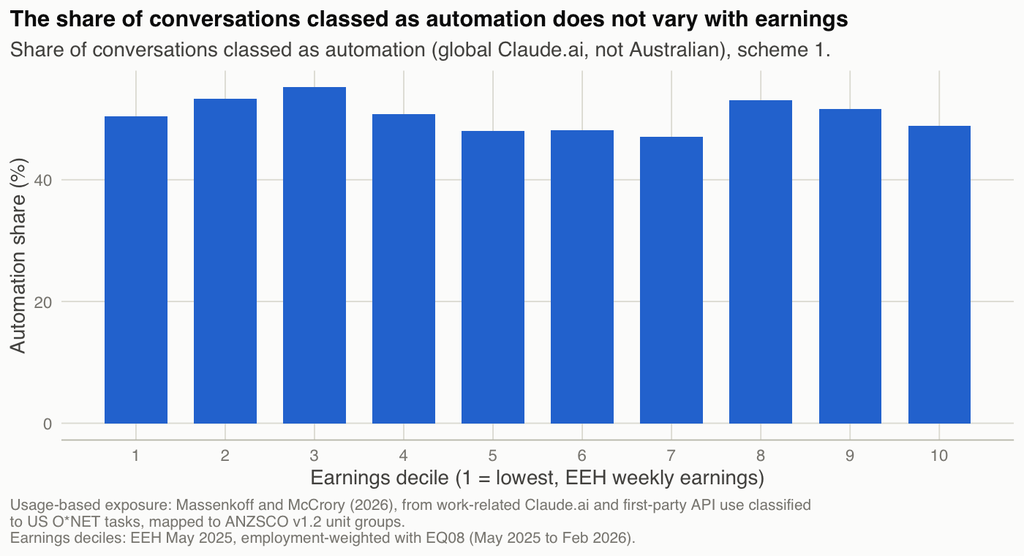

Share of global Claude.ai conversations classed as automation, averaged by earnings decile (scheme 1). These shares are global, not Australian.

## 18 Rebuilding the usage-based score from task data

The published occupation scores were rebuilt from the published task-level values, using O*NET task weights in place of the time fractions Massenkoff and McCrory use, which are not published. The rank correlation with the published scores falls short of the 0.9 target. The correlation among occupations with a positive published score (added after the first results) shows how much of the agreement comes from matching zeros. The main analysis uses the published scores.

| Task weights | SOC codes compared | Spearman | Agreement on exact zeros | Positive scores | Spearman, positive scores | Meets target |
| --- | --- | --- | --- | --- | --- | --- |
| equal | 756 | 0.871 | 93% | 345 | 0.816 | no |
| importance | 748 | 0.869 | 93% | 342 | 0.827 | no |
| importance × relevance | 748 | 0.870 | 93% | 342 | 0.840 | no |

## 19 The two-capital model: premium and benchmark responses

The main text states the responses of the skill premium to ICT, machinery and AI capital. With competitive wages, the skill premium in the thesis’s model is
$$\pi=c_\pi\left(\frac{V}{X}\right)^{1/\sigma_{VX}}\left(\frac{X}{S}\right)^{1/\sigma_{XS}}\left(\frac{U}{V}\right)^{1/\sigma_{VU}}\frac{A^S}{A^U},$$
with $s_I=(1-\mu)(K^I)^{\eta_X}/X^{\eta_X}$ ICT’s cost share in the skilled branch, $s_S=1-s_I$, and $s_M$ and $s_U=1-s_M$ defined likewise in the unskilled branch. Differentiating $\ln\pi$ with respect to $\ln K^I$ and $\ln K^M$ gives the benchmark responses in the main text; substituting $K^I+\zeta K^A$ for $K^I$ (scenario C) or $A^SN^S+\psi K^A$ for $S$ (scenario D) and applying the chain rule gives the two AI responses. If AI instead performs unskilled tasks, $U\to A^UN^U+\psi K^A$, then
$$\frac{\partial\ln\pi}{\partial\ln K^A}=\frac{\psi K^A}{U}\left[\frac{s_U}{\sigma_{VX}}+\frac{1-s_U}{\sigma_{VU}}\right]>0.$$
Every expression is checked symbolically and numerically in `theory/check_theory.py`, with output in `theory/check_theory_output.txt`. The responses hold technology fixed; how directed technical change would respond to AI is not derived.

## 20 Data sources and licences

Commit hashes are shortened to twelve characters; `data/raw/MANIFEST.csv` gives them in full, with each file’s URL and checksum.

| Source | Version | Licence |
| --- | --- | --- |
| aei_card | 4e5f69fab13a | CC-BY (version not stated on dataset card); HF metadata tag: MIT |
| aei_job_exposure | 4e5f69fab13a | CC-BY (version not stated on dataset card); HF metadata tag: MIT |
| aei_task_penetration | 4e5f69fab13a | CC-BY (version not stated on dataset card); HF metadata tag: MIT |
| aei_claude_ai_2026_06_26 | 4e5f69fab13a | CC-BY (version not stated on dataset card); HF metadata tag: MIT |
| aei_doc_2026_06_26 | 4e5f69fab13a | CC-BY (version not stated on dataset card); HF metadata tag: MIT |
| mm_appendix | 5 Mar 2026 | Not stated |
| onet_task_statements | O*NET 31.0 | CC BY 4.0 |
| onet_task_ratings | O*NET 31.0 | CC BY 4.0 |
| onet_occupation_data | O*NET 31.0 | CC BY 4.0 |
| abs_v12_isco08 | ANZSCO 2013 v1.2, released 4 Oct 2013 | CC BY 4.0 |
| abs_v12_structure | ANZSCO 2013 v1.2 | CC BY 4.0 |
| abs_v13_isco08 | ANZSCO 2013 v1.3, released 5 Nov 2019 | CC BY 4.0 |
| abs_v13_structure | ANZSCO 2013 v1.3 | CC BY 4.0 |
| abs_v13_whatsnew | ANZSCO 2013 v1.3 | CC BY 4.0 |
| abs_2021_correspondence | ANZSCO 2021 | CC BY 4.0 |
| abs_2021_structure | ANZSCO 2021 | CC BY 4.0 |
| abs_2022_correspondence | ANZSCO 2022 | CC BY 4.0 |
| abs_2022_structure | ANZSCO 2022 | CC BY 4.0 |
| abs_eq08 | Labour Force, Australia, Detailed, March 2026 | CC BY 4.0 |
| abs_eeh_cubes | Employee Earnings and Hours, May 2025 (released 23 Jan 2026) | CC BY 4.0 |
| abs_wa_table04 | Working arrangements, August 2025, Table 4 | CC BY 4.0 |
| ato_ts24_table15 | Taxation Statistics 2023-24, Individuals Table 15 | CC BY 2.5 AU |
| jsa_occupations_8 | Our Gen AI Transition (14 Aug 2025) | CC BY 4.0 |
| eloundou_occ_level | 0471612fef3c | MIT |
| aioe_appendix | adca5fc2cd0e | None stated |
| aioe_lm | adca5fc2cd0e | None stated |
| lmi_anzsco_onetsoc | Internet Archive capture 15 Mar 2024; ANZSCO 2013 v1.2 (per the file’s Notes sheet) | CC BY 4.0 |
| wwai_applicability | 550c00c9d1b0 | CC BY 4.0 |
| wwai_soc_metrics | 550c00c9d1b0 | CC BY 4.0 |
| wwai_licence | 550c00c9d1b0 | CC BY 4.0 |
| dn_workathome | 3ebab4f646ed | GPL-3.0 |
| dn_licence | 3ebab4f646ed | GPL-3.0 |
| bls_soc_2010_2018 | SOC 2010 to 2018 | US Government work, public domain |
| bls_isco_soc | ISCO-08 to SOC 2010 | US Government work, public domain |
| bls_oews_2025 | OEWS May 2025 national | US Government work, public domain |

## 21 Edition bridge: ANZSCO 2022 to v1.2

Unit-group pairs that do not keep the same code. The full table is `data/interim/bridge_2022units_v12units.csv`.

| 2022 unit | v1.2 unit | v1.2 title | Six-digit links | Type |
| --- | --- | --- | --- | --- |
| 1215 | 1212 | Crop Farmers | 4 | merge (several 2022 units into one v1.2 unit) |
| 1216 | 1212 | Crop Farmers | 10 | merge (several 2022 units into one v1.2 unit) |
| 1217 | 1212 | Crop Farmers | 1 | many-to-many |
| 1217 | 1214 | Mixed Crop and Livestock Farmers | 2 | split (one 2022 unit into several v1.2 units) |
| 2233 | 2232 | ICT Trainers | 1 | split (one 2022 unit into several v1.2 units) |
| 2233 | 2233 | Training and Development Professionals | 1 | split (one 2022 unit into several v1.2 units) |
| 2254 | 2254 | Technical Sales Representatives | 3 | merge (several 2022 units into one v1.2 unit) |
| 2341 | 2254 | Technical Sales Representatives | 1 | many-to-many |
| 2341 | 2341 | Agricultural and Forestry Scientists | 5 | split (one 2022 unit into several v1.2 units) |
| 2341 | 2345 | Life Scientists | 2 | many-to-many |
| 2345 | 2345 | Life Scientists | 9 | merge (several 2022 units into one v1.2 unit) |
| 2346 | 2346 | Medical Laboratory Scientists | 1 | split (one 2022 unit into several v1.2 units) |
| 2346 | 2349 | Other Natural and Physical Science Professionals | 1 | many-to-many |
| 2349 | 2349 | Other Natural and Physical Science Professionals | 6 | merge (several 2022 units into one v1.2 unit) |
| 2611 | 2611 | ICT Business and Systems Analysts | 2 | split (one 2022 unit into several v1.2 units) |
| 2611 | 2632 | ICT Support and Test Engineers | 1 | many-to-many |
| 2632 | 2632 | ICT Support and Test Engineers | 4 | merge (several 2022 units into one v1.2 unit) |
| 3625 | 3622 | Gardeners | 2 | merge (several 2022 units into one v1.2 unit) |
| 3626 | 3622 | Gardeners | 1 | merge (several 2022 units into one v1.2 unit) |
| 3627 | 3622 | Gardeners | 2 | merge (several 2022 units into one v1.2 unit) |
| 3633 | 3612 | Shearers | 1 | split (one 2022 unit into several v1.2 units) |
| 3633 | 3999 | Other Miscellaneous Technicians and Trades Workers | 1 | many-to-many |
| 3999 | 3999 | Other Miscellaneous Technicians and Trades Workers | 8 | merge (several 2022 units into one v1.2 unit) |
| 8421 | 8411 | Aquaculture Workers | 1 | recoded one-to-one |
| 8422 | 8412 | Crop Farm Workers | 12 | recoded one-to-one |
| 8423 | 8415 | Livestock Farm Workers | 10 | recoded one-to-one |
| 8424 | 8416 | Mixed Crop and Livestock Farm Workers | 2 | recoded one-to-one |
| 8431 | 8413 | Forestry and Logging Workers | 3 | recoded one-to-one |
| 8432 | 8414 | Garden and Nursery Labourers | 1 | merge (several 2022 units into one v1.2 unit) |
| 8433 | 8414 | Garden and Nursery Labourers | 1 | merge (several 2022 units into one v1.2 unit) |
| 8434 | 8419 | Other Farm, Forestry and Garden Workers | 1 | merge (several 2022 units into one v1.2 unit) |
| 8439 | 8419 | Other Farm, Forestry and Garden Workers | 3 | merge (several 2022 units into one v1.2 unit) |

## 22 Earnings imputations

Units without a published EEH value after bridging, and the parent level used. “none” means the unit has a published value in that source; “not imputed” means it has none and none was imputed (EEH cube 13 covers non-managerial employees only, so the chief executive, general manager and legislator units drop out of the hourly ranking).

| Unit | Title | EEH weekly | EEH cube 13 hourly | ATO |
| --- | --- | --- | --- | --- |
| 1111 | Chief Executives and Managing Directors | none | not imputed | none |
| 1112 | General Managers | none | not imputed | none |
| 1113 | Legislators | minor group (3-digit) mean | not imputed | none |
| 1211 | Aquaculture Farmers | minor group (3-digit) mean | none | none |
| 1212 | Crop Farmers | minor group (3-digit) mean | none | none |
| 1214 | Mixed Crop and Livestock Farmers | minor group (3-digit) mean | none | none |
| 1392 | Senior Non-commissioned Defence Force Members | minor group (3-digit) mean | none | none |
| 2522 | Complementary Health Therapists | minor group (3-digit) mean | none | none |
| 3221 | Metal Casting, Forging and Finishing Trades Workers | minor group (3-digit) mean | none | none |
| 3612 | Shearers | minor group (3-digit) mean | none | none |
| 3931 | Canvas and Leather Goods Makers | minor group (3-digit) mean | none | none |
| 3994 | Jewellers | minor group (3-digit) mean | none | none |
| 3996 | Signwriters | minor group (3-digit) mean | none | none |
| 4411 | Defence Force Members - Other Ranks | minor group (3-digit) mean | none | none |
| 4513 | Funeral Workers | minor group (3-digit) mean | none | none |
| 4515 | Personal Care Consultants | minor group (3-digit) mean | none | none |
| 5614 | Mail Sorters | minor group (3-digit) mean | none | none |
| 6111 | Auctioneers, and Stock and Station Agents | minor group (3-digit) mean | none | none |
| 6217 | Street Vendors and Related Salespersons | minor group (3-digit) mean | none | none |
| 6399 | Other Sales Support Workers | none | none | minor group (3-digit) mean |
| 8411 | Aquaculture Workers | minor group (3-digit) mean | none | none |
| 8413 | Forestry and Logging Workers | minor group (3-digit) mean | none | none |

## 23 Units without usage-based exposure

| Unit | Title | Employment (’000) | Share of employment |
| --- | --- | --- | --- |
| 4221 | Education Aides | 132.5 | 0.90% |
| 6392 | Retail and Wool Buyers | 6.1 | 0.04% |
| 1392 | Senior Non-commissioned Defence Force Members | 0.3 | 0.00% |

## 24 Primary chain against the 2022-path chain

Units whose linked US occupations differ between the two chains.

| Unit | Title | Primary links | 2022-path links | Jaccard | Only in primary | Only in 2022 path |
| --- | --- | --- | --- | --- | --- | --- |
| 1212 | Crop Farmers | 5 | 6 | 0.83 |  | 45-2021 |
| 2254 | Technical Sales Representatives | 2 | 14 | 0.14 |  | 19-1011; 19-1012; 19-1013; 19-1021; 19-1022; 19-1023; 19-1029; 19-1041; 19-1042; 19-1099; 19-1032; 25-9021 |
| 2341 | Agricultural and Forestry Scientists | 3 | 14 | 0.21 |  | 19-1011; 19-1012; 19-1021; 19-1022; 19-1023; 19-1029; 19-1041; 19-1042; 19-1099; 41-1012; 41-4011 |
| 2345 | Life Scientists | 10 | 14 | 0.71 |  | 19-1032; 25-9021; 41-1012; 41-4011 |
| 3321 | Floor Finishers | 4 | 7 | 0.57 |  | 47-2051; 47-2053; 47-4091 |
| 4111 | Ambulance Officers and Paramedics | 10 | 11 | 0.91 |  | 29-1071 |
| 8415 | Livestock Farm Workers | 4 | 2 | 0.50 | 45-1011; 45-2021 |  |
| 8419 | Other Farm, Forestry and Garden Workers | 5 | 6 | 0.83 |  | 53-7062 |

## 25 US employment weights not taken directly from OEWS

| SOC | Title | Weight | Source |
| --- | --- | --- | --- |
| 13-1021 | Buyers and Purchasing Agents, Farm Products | 163,810 | OEWS broad group 13-1020 residual, split equally |
| 13-1022 | Wholesale and Retail Buyers, Except Farm Products | 163,810 | OEWS broad group 13-1020 residual, split equally |
| 13-1023 | Purchasing Agents, Except Wholesale, Retail, and Farm Products | 163,810 | OEWS broad group 13-1020 residual, split equally |
| 13-2022 | Appraisers of Personal and Business Property | 28,535 | OEWS broad group 13-2020 residual, split equally |
| 13-2023 | Appraisers and Assessors of Real Estate | 28,535 | OEWS broad group 13-2020 residual, split equally |
| 21-1011 | Substance Abuse and Behavioral Disorder Counselors | 245,965 | OEWS broad group 21-1010 residual, split equally |
| 21-1014 | Mental Health Counselors | 245,965 | OEWS broad group 21-1010 residual, split equally |
| 25-2055 | Special Education Teachers, Kindergarten | 130,430 | OEWS broad group 25-2050 residual, split equally |
| 25-2056 | Special Education Teachers, Elementary School | 130,430 | OEWS broad group 25-2050 residual, split equally |
| 25-9042 | Teaching Assistants, Preschool, Elementary, Middle, and Secondary School, Except Special Education | 473,450 | OEWS broad group 25-9040 residual, split equally |
| 25-9043 | Teaching Assistants, Special Education | 473,450 | OEWS broad group 25-9040 residual, split equally |
| 25-9049 | Teaching Assistants, All Other | 473,450 | OEWS broad group 25-9040 residual, split equally |
| 29-2011 | Medical and Clinical Laboratory Technologists | 166,470 | OEWS broad group 29-2010 residual, split equally |
| 29-2012 | Medical and Clinical Laboratory Technicians | 166,470 | OEWS broad group 29-2010 residual, split equally |
| 31-1121 | Home Health Aides | 2,152,905 | OEWS broad group 31-1120 residual, split equally |
| 31-1122 | Personal Care Aides | 2,152,905 | OEWS broad group 31-1120 residual, split equally |
| 39-7011 | Tour Guides and Escorts | 26,750 | OEWS broad group 39-7010 residual, split equally |
| 39-7012 | Travel Guides | 26,750 | OEWS broad group 39-7010 residual, split equally |
| 47-4091 | Segmental Pavers | 14,190 | OEWS broad group 47-4090 residual, split equally |
| 47-4099 | Construction and Related Workers, All Other | 14,190 | OEWS broad group 47-4090 residual, split equally |
| 51-2022 | Electrical and Electronic Equipment Assemblers | 123,485 | OEWS broad group 51-2020 residual, split equally |
| 51-2023 | Electromechanical Equipment Assemblers | 123,485 | OEWS broad group 51-2020 residual, split equally |
| 51-2092 | Team Assemblers | 702,515 | OEWS broad group 51-2090 residual, split equally |
| 51-2099 | Assemblers and Fabricators, All Other | 702,515 | OEWS broad group 51-2090 residual, split equally |
| 53-1042 | First-Line Supervisors of Helpers, Laborers, and Material Movers, Hand | 155,910 | OEWS broad group 53-1040 residual, split equally |
| 53-1043 | First-Line Supervisors of Material-Moving Machine and Vehicle Operators | 155,910 | OEWS broad group 53-1040 residual, split equally |
| 53-1044 | First-Line Supervisors of Passenger Attendants | 155,910 | OEWS broad group 53-1040 residual, split equally |
| 53-1049 | First-Line Supervisors of Transportation Workers, All Other | 155,910 | OEWS broad group 53-1040 residual, split equally |
| 11-1031 | Legislators | 5,030 | no OEWS row; smallest published detailed employment in its SOC major group |
| 45-3031 | Fishing and Hunting Workers | 1,330 | no OEWS row; smallest published detailed employment in its SOC major group |

US military occupations (SOC major group 55) have no OEWS employment and no usage-based exposure, so they carry no weight.

## 26 AEI occupation-group shares: published mass and suppressed cells

| Geography | Month | Published share (%) | Groups published |
| --- | --- | --- | --- |
| AU-WA | 2026-04 | 97.46 | 18 |
| AU-WA | 2026-05 | 98.67 | 19 |
| AUS | 2026-04 | 97.63 | 22 |
| AUS | 2026-05 | 98.90 | 22 |
| GLOBAL | 2026-04 | 94.58 | 22 |
| GLOBAL | 2026-05 | 98.74 | 22 |

| Geography | Month | SOC major group | Name |
| --- | --- | --- | --- |
| AU-WA | 2026-04 | 37 | Building and Grounds Cleaning and Maintenance |
| AU-WA | 2026-04 | 45 | Farming, Fishing, and Forestry |
| AU-WA | 2026-04 | 47 | Construction and Extraction |
| AU-WA | 2026-04 | 53 | Transportation and Material Moving |
| AU-WA | 2026-05 | 37 | Building and Grounds Cleaning and Maintenance |
| AU-WA | 2026-05 | 45 | Farming, Fishing, and Forestry |
| AU-WA | 2026-05 | 47 | Construction and Extraction |

## 27 Draft list of owner-operator units

Excluded in one sensitivity run. This is a judgement list awaiting review (see the Methods section).

| Unit | Title |
| --- | --- |
| 1211 | Aquaculture Farmers |
| 1212 | Crop Farmers |
| 1213 | Livestock Farmers |
| 1214 | Mixed Crop and Livestock Farmers |
| 1411 | Cafe and Restaurant Managers |
| 1413 | Hotel and Motel Managers |
| 1421 | Retail Managers |
| 3312 | Carpenters and Joiners |
| 3322 | Painting Trades Workers |
| 3341 | Plumbers |
| 3411 | Electricians |
| 3911 | Hairdressers |
| 7311 | Automobile Drivers |